# Compare Timeseries of Network Stats Across Port Groups and to Other ESR Indicators

# 2. Graph Timeseries

## Figure x.Time series of node strength

… at WA and OR ports from 2004-2020. Node strength was derived from vessel-level networks summarized at the port level. Nodes (fisheries) are included in each network with a minimum total fisheries revenue cutoff for vessels of `$5,000` and a minimum revenue cutoff for individual fisheries of `$500`.

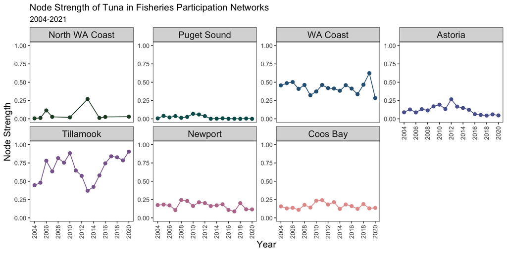

```r
plot_metric="Node Strength"
metric_label="Node Strength"
```

Save plot as a png, with filename: Node Strength of Tuna in Fisheries Participation Networks 2004-2021

## Figure y.Time series of importance

… at WA and OR ports from 2004-2020. Importance (eigenvalue centrality) was derived from vessel-level networks summarized at the port level. Nodes (fisheries) are included in each network with a minimum total fisheries revenue cutoff for vessels of `$5,000` and a minimum revenue cutoff for individual fisheries of `$500`.

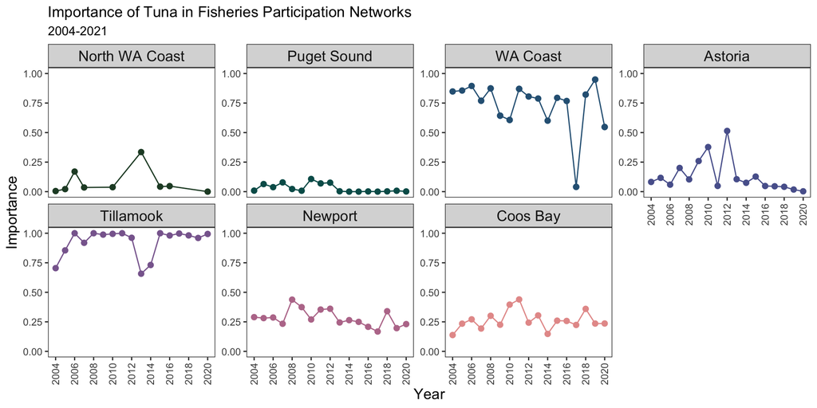

```r
plot_metric="Importance"
metric_label="Importance"
```

Save plot as a png, with filename: Importance of Tuna in Fisheries Participation Networks 2004-2021

## Figure z.Time series of HCI for Region 1

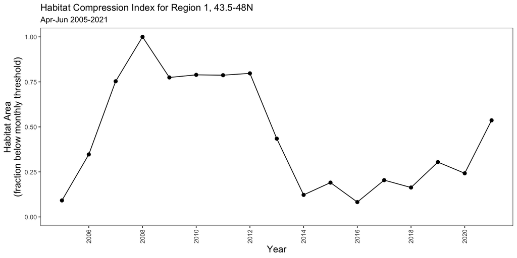

Save plot as a png, with filename: Spring Habitat Compression Index for Region 1, 43.5-48N, 2005-2021

## Figure aa. Time series of edge density

(Drop Other Coastal Washington & Unknown Ports & Columbia River)

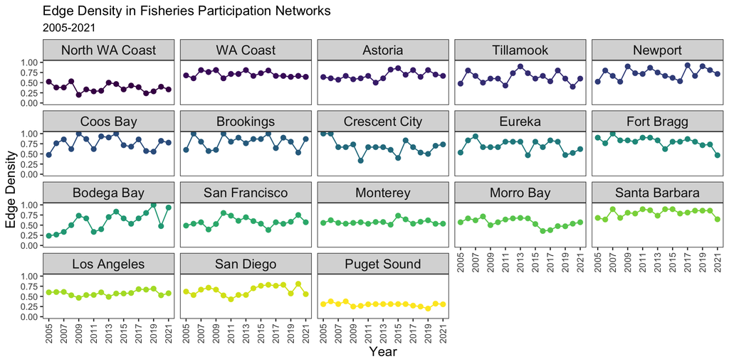

```r
plot_metric="Edge Density"
metric_label="Edge Density"
```

Save plot as a png, with filename: Edge Density in Fisheries Participation Networks 2004-2021